# 2.0_compile-trends-data

Devi Veytia

2025-07-08

```r
# general data handing
library(dplyr)
library(dbplyr)
library(R.utils)
```

```r
library(ggplot2)
library(ggalluvial)
library(tidyr)
library(stringr)
library(viridis)
library(countrycode)
library(broom)
library(conflicted)
library(tidyverse)
conflict_prefer("select", "dplyr")
```

```
## [conflicted] Will prefer dplyr::select over any other package.
```

```r
conflicts_prefer(dplyr::filter)
```

```
## [conflicted] Will prefer dplyr::filter over any other package.
```

```r
## AESTHETICS
factor_aes <- readxl::read_excel(here::here("R/mitigation_factor_aesthetics.xlsx"))
typeAES <- factor_aes[which(factor_aes$variable == "oro_type"),]
typeAES <- typeAES[order(typeAES$order),]
```

## Load data

Data structure: list with each level is - data frame for publications: - data frame for n policy documents - data frame for deployment

id variables: oro_type, component (publication, policy, deployment), variable_name, response variable: y

```r
load(here::here("data", "derived-data", "mitigationORO_pubs.RData")) #pubs
# load(here::here("data", "derived-data", "mitigationORO_pubsProp.RData"))
load(here::here("data", "derived-data", "n_nonBindPolicy_docs.RData")) # legDat
load(here::here("data", "derived-data", "n_legislation_docs.RData")) # polDat
load(here::here("data/derived-data/mitigationDeployDat.RData")) # allDeployDat
load(here::here("data/derived-data/mitigationPostsDat.RData")) # postsDat

year_lim <- c(2000, 2024)


# bind all data together
allComponentDat_model <- pubs %>%
  bind_rows(polDat) %>%
  bind_rows(legDat) %>%
  bind_rows(allDeployDat) %>%
  bind_rows(postsDat) %>%
  mutate(
    component = replace(component, component == "non-binding policy", "policy"),
    # y = scale(y, center=TRUE, scale=TRUE)
  ) %>%
  filter(year_lim[1] <= year & year <= year_lim[2])
```

# Transfer entropy

Publications:

- Behrendt et al. 2019. RTransferEntropy—Quantifyinginformationflowbetweendifferent timeseriesusingeffective transfer entropy
- **Amornbunchornvej et al 2021. Variable-lag Granger Causality and Transfer Entropy for Time Series Analysis**

Uses: To detect significance of information flow from X -> Y with a time lag. unlike Granger Causaility, can detect non-linear relationships.

Data Assumptions:

- evenly spaced, no NA (fill NAs with 0 in our time series)
- stationary data: refers to the idea that the statistical properties of a time series do not change over time. More specifically, a stationary time series is one in which the mean, variance, and autocorrelation structure are constant over time (no noticible changing levels, increasing variance). (use Box-Cox transform to make data normal)
- time lag is fixed (except see variable lag-Transfer entropy with bootstrapping, as bootstrapping approach increases the performance of transfer entropy methods in this task - install.packages(“VLTimeCausality”))

Pipeline:

- correct for heteroskedasity using a Box-Cox transformation to make your data normal (caret::BoxCoxTrans)
- get an iterable list of the pairwise edges for the different nodes in the time series
- Use VL-TE (bootstrapped) from the VLTTimeCausality package to get TE ratio and p-value (higher the ratio, stronger evidence for causality)
- Plot the TE ratio for each of the edges to determine the evidence for the relationship

```r
# remotes::install_github("DarkEyes/VLTimeSeriesCausality")
require(VLTimeCausality)

# Define levels to loop through

# Loop 1 -- different oros
oros <- unique(allComponentDat_model$oro_type)

# Loop 2 -- process all possible edges
# Define nodes and edges to process
nodes <- unique(allComponentDat_model$component)
edges <- expand.grid(nodes, nodes)
# edges <- edges[!apply(edges, 1, is.unsorted), ] # if order doesn't matter? if causality is tested in both directions...
edges <- edges[edges[,1] != edges[,2],]



# Function to make BoxCoxTransformation -- make data normal
BCTransform <- function(series){
  BCMod <- caret::BoxCoxTrans(series)
  series_trans <- predict(BCMod, series)
}

try_BCTransform <- function(series){
  tryCatch(
    {BCTransform(series)},
    error = function(e){
      return(series)
    }
  )
}


# Define function to only use BC transform is HeteroSkedasticity present?
correctHeteroskedasticity <- function(series, years){
  lmMod <- lm(series~years)
  isHet <- lmtest::bptest(lmMod)
  if(isHet$p.value <= 0.05){
    series_trans <- BCTransform(series)
    return(series_trans)
  }else{
    return(series)
  }
}
try_correctHeteroskedasticity <- function(series, years){
  tryCatch(
    {correctHeteroskedasticity(series, years)},
    error = function(e){
      return(series)
    }
  )
}



## Loop 1 -- loop through OROs
TE_results <- data.frame()
TE_results_summary <- data.frame()
for(oro in oros){
  # oro <- "MRE-Ocean" # for testing

  # Data processing
  # Fillin missing values with a 0 -- so that same years are represented across time series
  # correct for heteroskedasiticy
  oroDat <- allComponentDat_model %>%
    filter(oro_type == oro) %>%
    complete(component, year=year_lim[1]:year_lim[2],
             fill = list(y=0), explicit= FALSE) %>%
    group_by(component) %>%
    mutate(y_trans = try_BCTransform(y)) %>%
    ungroup()
  # ggplot(oroDat, aes(x=year, y=y_trans))+geom_line()+facet_wrap(vars(component), scales="free_y")



  edgesResults <- data.frame(
    oro_type = rep(oro, nrow(edges)),
    NodeX = edges[,1],
    NodeY = edges[,2],
    TE_XCauseY = rep(NA, nrow(edges)),
    TE_pval = rep(NA, nrow(edges)),
    TE_ratio = rep(NA, nrow(edges))
  )

  # Loop through the edges and test for causality
  for(e in 1:nrow(edges)){

    TE_out <- tryCatch(
      {VLTransferEntropy(
      Y= oroDat$y_trans[oroDat$component == edges[e,1]],
      X= oroDat$y_trans[oroDat$component == edges[e,2]],
      maxLag = 5,
      VLflag=TRUE,nboot=100, alpha = 0.05)},
      error = function(e){
        return(NULL)
      }
    )
    if(is.null(TE_out)){
      edgesResults$TE_pval[e] <- NA
      edgesResults$TE_XCauseY[e] <- NA
      edgesResults$TE_ratio[e] <- NA
    }else{
      edgesResults$TE_pval[e] <- TE_out$pval
      edgesResults$TE_XCauseY[e] <- TE_out$XgCsY_trns # TS$X causes TS$Y TRUE/FALSE
      edgesResults$TE_ratio[e] <- TE_out$TEratio
    }


  }

  # summarize results to most causal direction if a two-way effect found
  # ie. When TRUE for both directions, resolve by picking the direction with the highest TE ratio
  edgesResultsSummary <- data.frame()
  uniqueEdges <- edges[!apply(edges, 1, is.unsorted), ]
  for(ue in 1:nrow(uniqueEdges)){

    incl = vector(length = nrow(edgesResults))
    for(i in 1:nrow(edgesResults)){
      tmp <- c(edgesResults[i,c("NodeX","NodeY")]) %in% uniqueEdges[ue,]
      incl[i] <- sum(tmp)==2
    }
    tmpDat <- edgesResults[incl,] %>%
      filter(TE_XCauseY) %>%
      arrange(desc(TE_ratio)) %>%
      slice_head(n=1)

    edgesResultsSummary <- edgesResultsSummary %>%
      bind_rows(tmpDat)
  }


  # Bind results
  TE_results <- TE_results %>%
    bind_rows(edgesResults)
  TE_results_summary <- TE_results_summary %>%
    bind_rows(edgesResultsSummary)

}

# clean
rm(oroDat, nodes, edges, TE_out, edgesResults)



## Check data
# View(TE_results)
# View(TE_results_summary)
# TE_results %>% filter(!is.na(TE_XCauseY)) %>%filter(TE_XCauseY == TRUE)  %>% View


# save(TE_results, TE_results_summary, file = here::here("data/derived-data/TE_results.RData"))
```

```r
# Load results from previous chunk
load(here::here("data/derived-data/TE_results.RData")) # TE_results, TE_results_summary
```

# Changepoint sub-analysis

For efficiency and CCS, Efficiency and MRE-Ocean, looks like change points in deployment time series – what could have caused these increases? Could they be related to change points in other time series? While we cannot infer causality, we can say that these change points occur around the same time…

To explore this, fit a Bayesian multiple change point model (adapted from Cahill et al. 2015, doi: 10.1088/1748-9326/10/8/084002 for different distributions depending on response variable: ZIP for legislation and policy documents, Poisson for deployments for CDR-OAE, number of publications and number of posts, and Gamma for other deployment metrics and number of weighted posts as they are non-negative continuous data). This model estimates the number of probable change points, and then for each change point the posterior distribution.

```r
# The oro types to analyse
oroTypes = c("CCS","Efficiency","MRE-Ocean","CDR-OAE")
# The different time series components to analyse (e.g. deployment, legislation, policy, posts, etc)
components <- unique(allComponentDat_model$component)

# Jags initialization parameters
jagsInits <- list(
  # Maximum number of changepoints to look for
  "K_max"=2,
  # Time buffer for looking for change points.
  # i.e. don't find a change point at the first or last year
  "cpmin"="jagsData$MINX+1",
  "cpmax"="jagsData$MAXX-1")

# Compile all data into a list to iterate through
dataList <- list()
for(c in components){
  dataList[[c]] <- allComponentDat_model %>% filter(oro_type %in% oroTypes, component == c)

}

# Compile all model inputs into a list to iterate through
modelInputs <- list(
  "data" = dataList,
  "bugsModFiles" = list(
    "deployment" = "R/bugs-models/GammaModMultCP",
    "publications" = "R/bugs-models/PoissonModMultCP",
    "policy" = "R/bugs-models/ZIPModMultCP",
    "legislation" = "R/bugs-models/ZIPModMultCP",
    "public interest" = "R/bugs-models/PoissonModMultCP",
    "public interest weighted" = "R/bugs-models/GammaModMultCP",
    "public support" = "R/bugs-models/GammaModMultCP"
  ),
  "jagsData" = list(jagsInits)[rep(1,length(components))]
)



## Loop through all oro types and time series (components) to run change point analysis
cutpoint_results <- data.frame()
cutpoint_densities <- data.frame()

for(oro in oroTypes){
  # oro = "CCS"

  for(i in 1:length(components)){
    # i = 4

    print(paste(oro,":", components[i]))

    # get model to fit
    modFile <- modelInputs$bugsModFiles[[components[i]]]

    # If OAE deployment, y is poisson not Gamma so change
    if(components[i] == "deployment" & oro == "CDR-OAE"){
      modFile <- "R/bugs-models/PoissonModMultCP"
    }

    # Format data
    jagsData <- modelInputs$jagsData[[i]]
    myinits = list(.RNG.name = "base::Wichmann-Hill", .RNG.seed = 123)
    dat <- modelInputs$data[[components[i]]][modelInputs$data[[components[i]]]$oro_type == oro,]
    if(nrow(dat) < 5){
      print("Insufficient data")
      next
    }
    yearLims <- range(modelInputs$data[[i]][
      modelInputs$data[[components[i]]]$oro_type == oro,"year"
    ], na.rm=T)

    # Format specific inputs depending on the model
    if(grepl("pubBinom", modFile)){
      trialVar <- ifelse(grepl("ORO", modelInputs$y_variable[[i]]),
                         "n_OC","total_posts")
      successVar <- ifelse(grepl("ORO", modelInputs$y_variable[[i]]),
                         "n_ORO","n_posts")
      # if a proportion, only keep proportions of total values above 100 # modelInputs$y_variable[[i]] == "prop_ORO"
      keepYears <- dat$year[dat$variable_name == trialVar & 100 < dat$y]
      dat <- dat[dat$year %in% keepYears,]
      dat <- dat %>% arrange(variable_name, year)
      nTrial <- dat$y[dat$variable_name == trialVar]
      jagsData$nTrial <- nTrial
      jagsData$nSuccess <- dat$y[dat$variable_name == successVar]
      # datCast <- reshape2::dcast(dat, ... ~ variable_name, value.var = "y")
    }

    if(grepl("ZIP", modFile)){
      # if the model is zero inflated poisson,
      # Fill missing years with 0 values
      dat <- dat %>% tidyr::complete(year = yearLims[1]:yearLims[2])
      dat$y[is.na(dat$y)] <- 0
      dat <- dat %>% tidyr::fill(component, oro_type, variable_name)
      # add the latent binomial indicator, as to whether there are no documents at all
      myinits$w <- dat$y
      myinits$w[myinits$w > 0] <- 1

    }

    if(grepl("Poisson", modFile)){
      # Fill missing years with 0 values
      dat <- dat %>% tidyr::complete(year = yearLims[1]:yearLims[2])
      dat$y[is.na(dat$y)] <- 0
      dat$y <- round(dat$y) # force discrete y values
      dat <- dat %>% tidyr::fill(component, oro_type, variable_name)

    }

    if(grepl("Gamma", modFile)){
      # Fill missing years with 0 values
      dat <- dat %>% tidyr::complete(year = yearLims[1]:yearLims[2])
      dat$y[is.na(dat$y)] <- 0
      dat <- dat %>% tidyr::fill(component, oro_type, variable_name)
    }

    # make sure no NAs
    dat <- na.omit(dat)

    # Skip if after subsetting data there is insufficient data points
    if(nrow(dat) < 5){
      print("Insufficient data after subsetting")
      next
    }
    #with(dat, plot(year, y))

    jagsData$y <- dat$y
    jagsData$x <- dat$year
    jagsData$MINX <- min(jagsData$x)
    jagsData$MAXX <- max(jagsData$x)
    jagsData$cpmin <- eval(parse(text = jagsData$cpmin))
    jagsData$cpmax <- eval(parse(text = jagsData$cpmax))

    if((jagsData$cpmax-jagsData$cpmin)<5){
      jagsData$cpmin <- jagsData$MINX
      jagsData$cpmax <- jagsData$MAXX
    }



    ## Fit mdel
    bugs.model <- readChar(modFile, file.info(modFile)$size)

    jagsModel <- tryCatch(
      {
        rjags::jags.model(
          file = textConnection(bugs.model),
          data = jagsData,
          inits = myinits,
          n.chains = 3,
          n.adapt = 1500,
          quiet = FALSE
        )
        },
     error = function(e){
       return(NULL)
     }
    )
    if(is.null(jagsModel)){
      next
    }


    update(jagsModel, 1000) # burnin
    s = rjags::coda.samples(
          model = jagsModel,
          variable.names = c("alpha","beta","K","x_cp","z","pk"),
          n.iter = 1000,
          quiet = FALSE
        )

    qs <- summary(s)$quantile
    # qs
    # plot(s[,"pk[2]"]) # check mixing

    # Subset to only the change points that are likely
    # And if there are likely change points, only those that indicate a positive change
    K <- round(quantile(qs["K",], 0.5))
    if(grepl("ZIP", modFile)){
      K <- sum(0.5 <= qs[grepl("pk", rownames(qs)),"50%"])
    }

    if(K == 0){
      print("No significant change points")
      next
    }else{
      pk <- qs[grep("pk", rownames(qs)),"50%"] # probability for each change point
      x_cp <- qs[grep("x_cp", rownames(qs)),"50%"] # locations of each change point
      # arrange in order of decreasing probability to find the most K probable
      pkIndKeep <- order(pk, decreasing=T)
      pkIndKeep <- pkIndKeep[1:K]
      # then re-arrange in chronological order for calculating trends of segments
      pkIndKeep <- sort(pkIndKeep)

      # Find which change points mark a positive change in trend
      trends <- vector("numeric", K+1) # store the trend for each segment
      starts <- c(min(jagsData$x), round(x_cp[pkIndKeep]))
      ends <- c(round(x_cp[pkIndKeep]), max(jagsData$x))
      for(k in 1:(K+1)){
        if(grepl("Binom", modFile)){
          trends[k] <- jagsData$y[which.min(abs(jagsData$x-ends[k]))] - jagsData$y[which.min(abs(jagsData$x-starts[k]))]
        }else if(grepl("ZIP|Pois|Gamma", modFile)){
          trends[k] <- sum(jagsData$y[which.min(abs(jagsData$x-starts[k])):which.min(abs(jagsData$x-ends[k]))] )
        }

      }
      # only keep the positive changes in trends
      pkIndKeep <- pkIndKeep[which(0 < diff(trends))]

      if(length(pkIndKeep) == 0){
        print("no changepoints marking increasing trend")
        next
      }else{
        pkIndNames <- names(x_cp[pkIndKeep])

        # If there are two cut points within 3 years of each other,
        # keep most probable one
        if(1 < length(pkIndKeep)){
          if(diff(qs[pkIndNames,"50%"]) < 3){
            pkIndNames <- pkIndNames[1]
          }
        }

        # save probability density of the cut points for plotting
        calc_density <- function(vals){
          dens <- density(vals, n=100)
          return(data.frame("year"=dens$x, "cp_density"=dens$y))
        }
        densTemp <- do.call(rbind, s)
        densTemp <- as.matrix(densTemp[,pkIndNames], ncol=length(pkIndNames))
        densTemp <- do.call(rbind.data.frame, apply(densTemp, 2, function(x) calc_density(x)))
        densTemp$cp_id <- rep(pkIndNames, 100)[sort(rep(1:length(pkIndNames),100))]


        # Save summary of quantiles
        dfTemp <- do.call(rbind, apply(qs[pkIndNames,,drop=FALSE], 1, function(x) as.data.frame(x)))
        dfTemp$quantile = rep(colnames(qs), length(pkIndNames))
        dfTemp$cp_id <- rep(pkIndNames, 5)[sort(rep(1:length(pkIndNames),5))] #rep(1:length(pkIndNames), 5) %>% sort
        rownames(dfTemp) <- NULL
        # Cap the distribution of cutpoints at the hard limits of the data
        colnames(dfTemp)[which(colnames(dfTemp) == "x")] <- "year"
        dfTemp$year <- ifelse(dfTemp$year < yearLims[1], yearLims[1], dfTemp$year)
        dfTemp$year <- ifelse(yearLims[2] < dfTemp$year, yearLims[2], dfTemp$year)
        # Add id variables
        addIdVariables <- function(df){
          df %>% mutate(
                        oro_type = oro,
                        component = dat$component[1],
                        variable_name = dat$variable_name[1])
        }
        dfTemp <- addIdVariables(dfTemp)
        densTemp <- addIdVariables(densTemp)

        ## Bind data to results
        cutpoint_results <- rbind(cutpoint_results, dfTemp)
        cutpoint_densities <- rbind(cutpoint_densities, densTemp)
        # remove jags model
        rm(jagsModel)
      }
    }



  } # end looping through ORO types
} # end looping through bugs models



## Save results
# save(cutpoint_results,cutpoint_densities, file=here::here("outputs/cutpointResults_mitigation.RData"))
```

CP attribution - if a deployment cutpoint is identified what other cutpoints happened within -4 years + 2 years?

```r
# Load data from previous chunk
load(here::here("outputs/cutpointResults_mitigation.RData"))

oroTypes <- unique(cutpoint_results$oro_type)

attrCP_summary <- data.frame()
for(oro in oroTypes){
  depCP <- cutpoint_results %>%
    filter(component == "deployment", oro_type == oro, quantile == "50%")

  # For each deployment cutpoint, which other cutpoints ocurred within pm 2 years?
  for(cpid in unique(depCP$cp_id)){
    targetYear <- depCP$year[depCP$cp_id == cpid]
    attrCPs <- cutpoint_results %>%
      filter(component != "deployment", oro_type == oro, quantile == "50%",
             cp_id == cpid,
             year <= targetYear+2 & targetYear-4 <= year)

    attrCP_summary <- attrCP_summary %>%
      bind_rows(attrCPs)

  }

}

# View(cutpoint_results)
print(attrCP_summary)
```

```
##       year quantile   cp_id   oro_type                component
## 1 2004.117      50% x_cp[2] Efficiency              legislation
## 2 2013.326      50% x_cp[2]  MRE-Ocean              legislation
## 3 2009.069      50% x_cp[2]  MRE-Ocean public interest weighted
## 4 2014.261      50% x_cp[1]    CDR-OAE          public interest
## 5 2017.489      50% x_cp[1]    CDR-OAE public interest weighted
## 6 2015.619      50% x_cp[1]    CDR-OAE           public support
##                                variable_name
## 1                            Legislation (N)
## 2                            Legislation (N)
## 3          N posts (query and like-weighted)
## 4                   N posts (query-weighted)
## 5          N posts (query and like-weighted)
## 6 N positive posts (query and like-weighted)
```

When big changes happen, they co-occur with change in legislation and public interest/support…

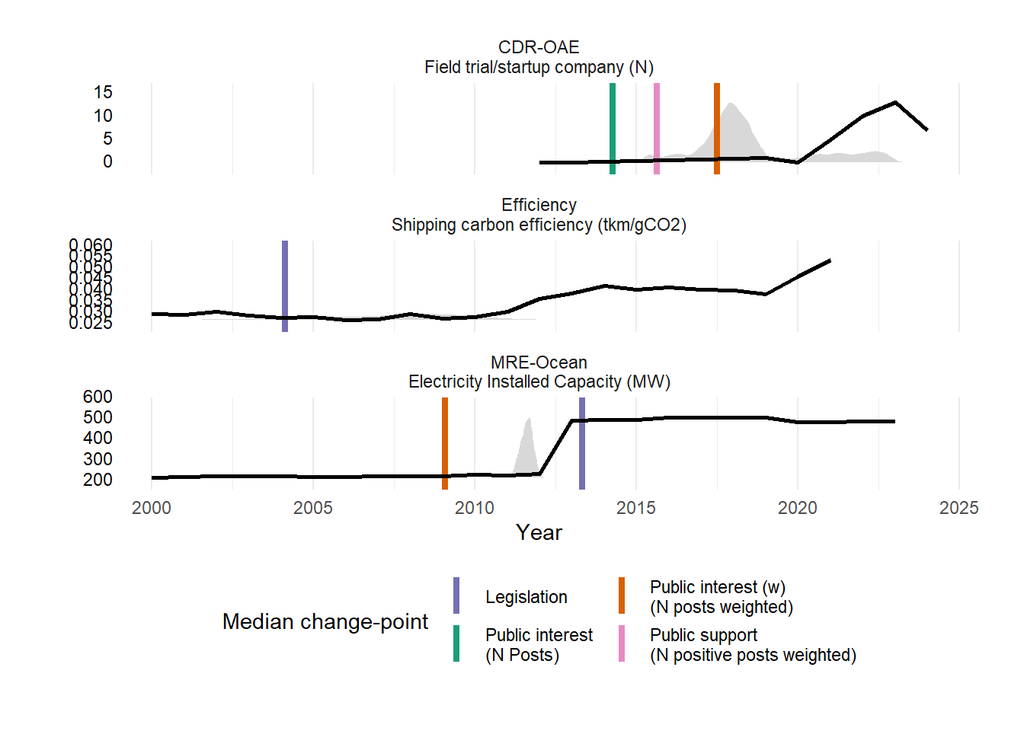

```r
yBackTransform <- function(value, ogRange, newRange){
  b <- diff(newRange) / diff(ogRange)
  a <- newRange[1] - b * ogRange[1]
  return(a + b * value)
}


# Get raw data to plot
cpDeployPlotData <- data.frame()
cpDensityPlotData <- data.frame()
yAxisBreaks <- data.frame()
for(oro in unique(attrCP_summary$oro_type)){

  rawDat <- allComponentDat_model %>%
    filter(oro_type == oro, component == "deployment") %>%
    mutate(y_scale = scales::rescale(y, c(0,1), na.rm=T)) %>%
    mutate(
      label = paste(
        scales::number(y, accuracy =1, scale_cut = append(scales::cut_long_scale(), 1, 1),
                       big.mark = ".", decimal.mark = ",")
      )
    )
  ogRange <- range(rawDat$y, na.rm=T)
  newRange <- c(0,1)
  ogBreaks <- pretty(ogRange, n = 4)
  newBreaks <- yBackTransform(ogBreaks, ogRange, newRange)
  if(1 < ogRange[2]){
    ybl <- scales::number(ogBreaks, accuracy =1, scale_cut = append(scales::cut_long_scale(), 1, 1),
                       big.mark = ",", decimal.mark = ".")
  }else{
    ybl <- scales::number(ogBreaks, accuracy =0.001, scale_cut = append(scales::cut_short_scale(), 1, 1),
                       big.mark = ",", decimal.mark = ".")
  }

  yAxisBreaks <- yAxisBreaks %>%
    bind_rows(
      data.frame(
        y_breaks = ogBreaks,
        y_breaks_label = ybl,
        y_scale_breaks = newBreaks,
        oro_type = oro,
        component = "deployment"
      )
    )

  cpDens <- cutpoint_densities %>%
    filter(component == "deployment") %>%
    mutate(cp_group = paste(oro, component, cp_id)) %>%
    group_by(cp_group) %>%
    mutate(
      cp_density = scales::rescale(cp_density, to=c(0,1))
    )

  cpDeployPlotData <- cpDeployPlotData %>% bind_rows(rawDat)
  cpDensityPlotData <- cpDensityPlotData %>% bind_rows(cpDens)

}

stripLabsDF <- cpDeployPlotData %>%
  distinct(oro_type, variable_name) %>%
  mutate(
    labels = paste(oro_type, variable_name, sep="\n")
  )
stripLabs <- stripLabsDF$labels
names(stripLabs) <-stripLabsDF$oro_type


changePoint_ggp <- ggplot()+
  geom_ribbon(data = cpDensityPlotData,
       aes(x=.data$year, ymax=.data$cp_density, ymin=0, group=.data$cp_group),
       fill = "lightgrey", alpha = 0.5)+ # , ymin=-Inf,
  geom_text(data = yAxisBreaks,
            aes(x=-Inf, y=.data$y_scale_breaks, label = .data$y_breaks_label),
            size = 3, col = "black", hjust = 1, vjust=0)+
  geom_vline(data = attrCP_summary,
             aes(xintercept=.data$year, col = .data$component, group = .data$cp_id),
             linewidth = 1.5)+
  # geom_rect(data = cutpoint_results %>%
  #            filter(paste(cp_id, oro_type, component) %in% with(attrCP_summary, paste(cp_id, oro_type, component))) %>%
  #            reshape2::dcast(...~quantile, value.var = "year"),
  #         aes(xmin = `25%`, xmax=`75%`, group=cp_id, fill = component), ymin=-Inf, ymax=Inf, alpha=0.5,
  #         inherit.aes = FALSE)+
  geom_line(data = cpDeployPlotData,
            aes(x=.data$year, y=.data$y_scale),
            col = "black", linewidth = 1)+
  scale_y_continuous(
    breaks = NULL, #pretty_breaks(n = 4),
    name = ""
  )+
  scale_x_continuous(name = "Year")+

  # Color scales
 scale_color_manual(name="Median change-point",
                  breaks = c("legislation","public interest","public interest weighted","public support" ),
                  labels =c("Legislation","Public interest\n(N Posts)","Public interest (w)\n(N posts weighted)","Public support\n(N positive posts weighted)"),
                  values = c("#7570b3","#1b9e77","#d95f02","#e78ac3")
                  )+
  # scale_fill_manual(name="Time series dataset",
  #                 breaks = c("legislation","public interest","public interest weighted","public support" ),
  #                 labels =c("Legislation","N Posts","N posts (weighted)","Public support"),
  #                 values = c("#7570b3","#1b9e77","#d95f02","#e78ac3")
  #                 )+
  guides(color = guide_legend(nrow = 2))+

  facet_wrap(vars(oro_type), ncol=1, labeller = labeller(oro_type = stripLabs))+
  coord_cartesian(clip = "off")+
  theme_minimal()+
  theme(
    axis.text.y = element_blank(),
    plot.margin = unit(c(0.5,1,1,1.5), units = "cm"),
    legend.position = "bottom"
  )

changePoint_ggp
```

```r
# ggsave(
#   here::here("figures/main/changePointTimeSeries.pdf"),
#   width = 7, height=8, units='in'
# )
```